# Pipeline validation: 10,000 BD trees from simulation to comparison

PhyloPOMP.jl, 2026-10-08

## How to build this page

```bash
quarto render docs/tutorial/validation_tutorial.qmd
```

Run it from the PhyloPOMP.jl directory. It writes `docs/tutorial/validation_tutorial.html`. Open that file in a browser.

On this machine, simulation of trees is about 10 seconds, encoding 20 seconds, training on a 3090 is about 2 minutes and then 1 minute of compiling, comparison and pipeline checks.

## What this run is

One small end-to-end run of the deep-learning pipeline, all in Julia, on the BD model (phylopomp’s LBDP: birth, death, and sampling that removes the host).

```
flowchart LR
  D["Draw R0, IP, p<br/>for each tree"] --> S["Simulate the tree<br/>stop rule: tips"]
  S --> E["Encode<br/>CBLV and summary statistics"]
  E --> T["Train CNN-CBLV and FFNN-SS<br/>8,500 trees, on the GPU"]
  T --> N["Network estimates<br/>500 test trees"]
  S --> L["Exact likelihood, lbdp_exact<br/>MLE on the same 500 trees"]
  N --> C["Compare each estimate<br/>with the tree's true values"]
  L --> C
```

1. Simulate 10,000 trees with the stopping rule of Voznica et al. (2022).
2. Encode every tree two ways: the CBLV vector for the CNN, and 98 summary statistics for the FFNN. Both equal phylodeep’s own encoders.
3. Train Voznica’s two networks, CNN-CBLV and FFNN-SS, each in two versions, on the GPU.
4. On 500 trees not used in training, compare the networks with maximum likelihood and with phylodeep’s pretrained networks, using Voznica’s measures.

BD has a closed-form exact likelihood: `lbdp_exact` (ported from R phylopomp) computes it directly, so the MLE here has no simulation noise. BDEI and BDSS have an exact likelihood too, from the multi-type birth-death equations solved numerically (`mtbd_exact`); models with a susceptible pool (SEIR, …) need the particle filter, `mgp_filter_pomp` with `mif`. On BD, `mif` reached the exact MLE to within 0.07 log-likelihood units on 4 trees (`pipeline/fit_lbdp.jl`), so BD is the place to check the filter route before trusting it on the other models. Voznica used an exact formula (TreePar) for BD and BEAST2 for BDEI and BDSS.

This run checks that every piece works and gives sensible numbers. It is not the full replication: Voznica trained on 3,990,000 trees; this run trains on 8,500.

## Setup

```julia
import Pkg
Pkg.activate(joinpath(@__DIR__, "validation"))
Pkg.instantiate()

using PhyloPOMP, CSV, DataFrames, Statistics, Printf, TOML
using Random: Xoshiro
import CairoMakie   # loading a Makie backend turns on `genealogyplot`
using CairoMakie: Figure, Axis, Point2f, lines!, scatter!, hist!, ablines!, axislegend, stairs!, hspan!,
                  vlines!, hlines!, text!, linesegments!

const ROOT     = normpath(joinpath(@__DIR__, "..", ".."))
const RUN      = joinpath(ROOT, "output", "val10k")        # this run: stop=tips
const TIME_RUN = joinpath(ROOT, "output", "val3k_time")    # 3,000 trees with stop=time, for section 1
const FORCE    = false          # true: redo every step
const DEVICE   = "gpu"          # "cpu" without an NVIDIA GPU
const JULIA    = joinpath(Sys.BINDIR, "julia")

## Run one pipeline script (in the pipeline environment, 16 threads) unless its output exists in `dir`.
## Its printed output goes to <dir>/<name>.log.
function step(name, script, args, output; dir = RUN)
    log = joinpath(dir, "$name.log")
    if FORCE || !isfile(joinpath(dir, output))
        mkpath(dir)
        cmd = `$JULIA -t 16 --project=$(joinpath(ROOT, "pipeline")) $(joinpath(ROOT, "pipeline", script)) $args`
        t = @elapsed run(pipeline(cmd; stdout = log, stderr = log))
        @printf("%s: ran now, %.0f s\n", name, t)
    else
        println(name, ": using results written ", Libc.strftime("%Y-%m-%d %H:%M", mtime(joinpath(dir, output))))
    end
    log
end;
```

```
  Activating project at `~/Desktop/Projects/PhyloPOMP.jl/docs/tutorial/validation`
```

# Part 1: the data

## 1. Two ways to stop a simulation

Every tree starts from one infected host, with its own R0, infectious period (IP) and sampling probability (p). Hosts infect others; each infected host stops being infectious after a while, and when it does it is sampled with probability p. Each sample is a tip of the tree. Something has to decide when the simulation stops. `generate_trees.jl` has two rules, chosen with `stop=tips` or `stop=time`.

**`tips`, Voznica’s rule** (Methods Extended p. 30):

1. Draw the tree size t, between 50 and 199.
2. Run the epidemic and stop at the moment of the t-th sample.
3. If the epidemic dies out first, start again with the same R0, IP and p, up to 100 times; then draw new values.

Every tree has exactly the size that was drawn, and it ends at its last sample.

**`time`, the rule of the R script `generate_data_phylopomp.R`:**

1. Draw a target size between 50 and 199.
2. Compute T = log(target) / r, with growth rate r = (R0 − 1)/IP: the time the number of infected hosts needs to grow from 1 to the target.
3. Run the epidemic until time T. Keep the tree only if it has 50 to 199 tips; otherwise try again, up to 100 times, each try limited to 1 second.

One simulated epidemic, showing where each rule stops it:

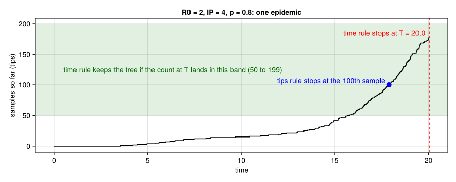

```julia
θ_ex = let R0 = 2.0, IP = 4.0, p = 0.8
    (λ = R0 / IP, μ = (1 - p) / IP, ψ = 0.0, χ = p / IP)
end
T_ex = log(150) / (θ_ex.λ - θ_ex.μ - θ_ex.χ)        # time rule, target 150
t_ex = 100                                           # tips rule, tree size 100
traj = nothing
for seed in 1:500
    tr = simulate_trajectory(LBDP, θ_ex; x0 = (n = 1,), graft = [1], tmax = T_ex, rng = Xoshiro(seed))
    if count(==(:sampling_remove), tr.events) ≥ 120
        global traj = tr
        break
    end
end
ts = traj.times[2:end][traj.events .== :sampling_remove]       # times of the samples
fig = Figure(size = (900, 360))
ax = Axis(fig[1, 1]; xlabel = "time", ylabel = "samples so far (tips)",
          title = "R0 = 2, IP = 4, p = 0.8: one epidemic")
hspan!(ax, 50, 199; color = (:green, 0.12))
stairs!(ax, [0.0; ts; T_ex], [0; 1:length(ts); length(ts)]; step = :post, color = :black)
scatter!(ax, [ts[t_ex]], [t_ex]; color = :blue, markersize = 14)
text!(ax, ts[t_ex], t_ex; text = "tips rule stops at the 100th sample  ", color = :blue, align = (:right, :bottom))
vlines!(ax, [T_ex]; color = :red, linestyle = :dash)
text!(ax, T_ex, length(ts); text = "time rule stops at T = $(round(T_ex, digits = 1))  ", color = :red,
      align = (:right, :bottom))
text!(ax, 0.5, 125; text = "time rule keeps the tree if the count at T lands in this band (50 to 199)",
      color = :darkgreen, align = (:left, :center))
fig
```

Both rules give a tree here. They differ in three ways.

**1. Which trees end up in the data.** Under `time`, the number of tips at T depends on the parameters: roughly p/(R0 − 1) × target. Trees with a low sampling probability have few tips at T and are thrown away. Under `tips`, every draw gives a tree of the drawn size. This run (10,000 trees, `tips`) and a set of 3,000 trees made with `time`:

```julia
step("generate", "generate_trees.jl", ["small", "10000", RUN, "42", "stop=tips"], "trees.tsv")
step("generate", "generate_trees.jl", ["small", "3000", TIME_RUN, "101", "stop=time"], "trees.tsv"; dir = TIME_RUN)
trees = CSV.read(joinpath(RUN, "trees.tsv"), DataFrame; delim = '\t')
timetrees = CSV.read(joinpath(TIME_RUN, "trees.tsv"), DataFrame; delim = '\t')
for (lab, d) in (("tips", trees), ("time", timetrees))
    @printf("stop=%s: %5d trees, %4.1f%% with p < 0.1, %4.1f%% with p < 0.2\n", lab, nrow(d),
            100mean(d.p_sample .< 0.1), 100mean(d.p_sample .< 0.2))
end
println("the draw itself puts 9.1% below 0.1 and 19.2% below 0.2")
```

```
generate: using results written 2026-10-08 15:36
generate: using results written 2026-10-08 17:08
stop=tips: 10000 trees,  9.1% with p < 0.1, 18.4% with p < 0.2
stop=time:  3000 trees,  2.6% with p < 0.1, 10.9% with p < 0.2
the draw itself puts 9.1% below 0.1 and 19.2% below 0.2
```

The `time` data hold far fewer low-sampling trees than the draw asked for; the `tips` data hold what was drawn.

**2. What the tree records.** Under `tips` the tree ends at its last sample and nothing is cut off, so `lbdp_exact` on the tree as it ends is the likelihood of the simulation that made it. One factor is left out: an epidemic that dies out before its t-th sample is rerun, so every kept tree is conditioned on reaching t samples, and the likelihood of the data as made is `lbdp_exact` divided by P(reach t samples | R0, p). That probability has a closed form (`scripts/bd_conditioning.jl`). It is close to the survival probability 1 − 1/R0 when R0 is well above 1 and larger near R0 = 1, where it matters most: 0.083 against 0.048 at R0 1.05, p 0.5, t = 50. On the 500 test trees, dividing by it lowers the MLE’s R0 bias from +6.8% to +4.4% and its MAPE from 15.6% to 15.3%; the MLE below does not include it. Under `time` the epidemic ran on from the last sample to T without another sample, and the tree does not show T. Leaving that stretch out changes the likelihood; putting T in would give the MLE a number computed from the true R0 and IP, which the networks never see.

**3. What it matches.** `tips` is how Voznica’s training data were made. `time` stops each tree at a fixed time.

This run uses `tips`.

## 2. The 10,000 trees

Each tree’s parameters are drawn independently and uniformly: R0 from 1 to 5, IP from 1 to 10, p from 0.01 to 1. These ranges are the prior. The single draw for a tree is that tree’s true values.

```julia
cfg = TOML.parsefile(joinpath(RUN, "config.toml"))
println("stop rule: ", cfg["stop"], "; trees: ", nrow(trees), "; tips: ", extrema(trees.ntips))
println("simulations per tree: median ", median(trees.attempts),
        ", 99th percentile ", round(quantile(trees.attempts, 0.99), digits = 1), ", maximum ", maximum(trees.attempts))
for (lo, hi) in ((1, 1), (2, 10), (11, 100))
    s = trees[lo .<= trees.attempts .<= hi, :]
    @printf("needed %d to %d simulations: %5d trees, mean R0 %.2f\n", lo, hi, nrow(s), mean(s.R_0))
end
```

```
stop rule: tips; trees: 10000; tips: (50, 199)
simulations per tree: median 1.0, 99th percentile 18.0, maximum 95
needed 1 to 1 simulations:  6024 trees, mean R0 3.34
needed 2 to 10 simulations:  3707 trees, mean R0 2.56
needed 11 to 100 simulations:   269 trees, mean R0 1.15
```

Most trees come from the first simulation. The trees that need many restarts have R0 close to 1, where an epidemic usually dies out early.

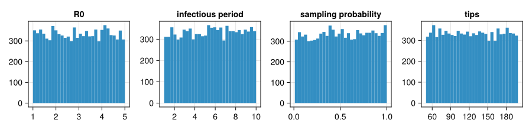

```julia
fig = Figure(size = (900, 220))
for (k, (col, lab)) in enumerate(((:R_0, "R0"), (:Infectious_Period, "infectious period"),
                                  (:p_sample, "sampling probability"), (:ntips, "tips")))
    hist!(Axis(fig[1, k]; title = lab), trees[!, col]; bins = 30)
end
fig
```

The three parameters are flat over their ranges, and tree size is flat over 50 to 199 by construction.

One of the 500 test trees:

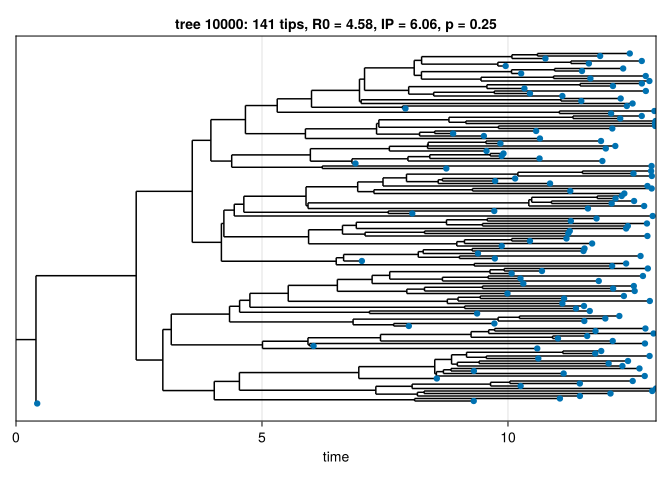

```julia
g = parse_newick(String(trees.newick[end]))
genealogyplot(g, title = @sprintf("tree %d: %d tips, R0 = %.2f, IP = %.2f, p = %.2f",
                                  trees.tree[end], nsample(g), trees.R_0[end], trees.Infectious_Period[end],
                                  trees.p_sample[end]))
```

## 3. Encode the trees

`encode_trees.jl` writes two inputs per tree to `cblv.h5`:

1. CBLV, 402 numbers: the tree’s branch lengths in Voznica’s ladderized order, divided by the mean branch length (the “rescale factor”), padded with zeros, plus p twice.
2. Summary statistics, 99 numbers: 98 statistics of the tree (branch lengths, imbalance, lineages through time, transmission chains) plus p.

```julia
step("encode", "encode_trees.jl", [RUN], "cblv.h5")
```

```
encode: using results written 2026-10-08 15:50
```

```
"/home/inferno/Desktop/Projects/PhyloPOMP.jl/output/val10k/encode.log"
```

Both encoders are checked against phylodeep itself (Python, used only as a reference) by the pipeline tests:

```julia
testlog = joinpath(RUN, "pipeline_tests.log")
if FORCE || !isfile(testlog)
    run(pipeline(`$JULIA --project=$(joinpath(ROOT, "pipeline")) $(joinpath(ROOT, "pipeline", "test", "runtests.jl"))`;
                 stdout = testlog, stderr = testlog))
end
foreach(println, filter(l -> occursin(r"Test Summary|pipeline vs phylodeep", l), readlines(testlog)))
```

```
Test Summary:         | Pass  Total  Time
pipeline vs phylodeep |  204    204  8.8s
```

Every check passes: on 33 trees the Julia CBLV equals phylodeep’s to about 1e-13 and the summary statistics to about 1e-14, and the networks loaded with phylodeep’s pretrained weights give Keras’s outputs to about 1e-7.

# Part 2: the networks

## 4. Train on the GPU

Two networks, each in two versions:

| Network | Input | Layers |
| --- | --- | --- |
| CNN-CBLV | CBLV | three 1-D convolutions, pooling, then dense 64, 32, 16, 8, 2 |
| FFNN-SS | summary statistics, standardized | dense 64, 32, 16, 8, 2 |

| Version | Dropout | 8-unit layer | Source |
| --- | --- | --- | --- |
| `released` | none | ELU | phylodeep’s released models |
| `paper` | 0.5 | ELU | Methods Extended text and figure caption |

Both predict R0 and the infectious period divided by the rescale factor. Training follows Voznica: MAPE as the loss, Adam, and early stopping on a validation set (here 1,000 trees). One change for this size: batches of 500 trees instead of Voznica’s 8,000, which on 8,500 training trees would give only 2 updates per pass.

```
train: using results written 2026-10-08 15:47
```

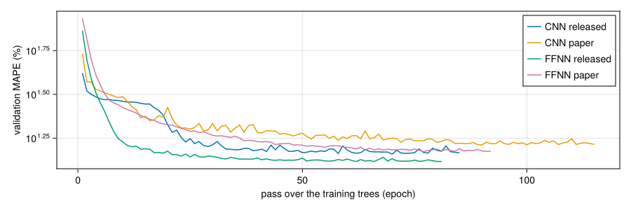

```julia
step("train", "train_dl.jl", [RUN, "net=both", "arch=both", "epochs=200", "batch=500", "patience=15",
                              "device=$DEVICE"], "ffnn_paper_test.csv")
variants = [(net, arch) for net in ("cnn", "ffnn") for arch in ("released", "paper")]
fig = Figure(size = (900, 300))
ax = Axis(fig[1, 1]; xlabel = "pass over the training trees (epoch)", ylabel = "validation MAPE (%)", yscale = log10)
for (net, arch) in variants
    h = CSV.read(joinpath(RUN, "$(net)_$(arch)_history.csv"), DataFrame)
    lines!(ax, h.epoch, h.val_loss; label = "$(uppercase(net)) $arch")
end
axislegend(ax)
fig
```

```julia
trained = DataFrame(version = String[], epochs = Int[], best_validation_MAPE = Float64[], seconds = Float64[])
for (net, arch) in variants
    h = CSV.read(joinpath(RUN, "$(net)_$(arch)_history.csv"), DataFrame)
    push!(trained, ("$(uppercase(net)) $arch", nrow(h), round(minimum(h.val_loss), digits = 2),
                    round(sum(h.seconds), digits = 1)))
end
trained
```

4×4 DataFrame

| Row | version String | epochs Int64 | best_validation_MAPE Float64 | seconds Float64 |
| --- | --- | --- | --- | --- |
| 1 | CNN released | 85 | 14.41 | 54.4 |
| 2 | CNN paper | 115 | 16.28 | 18.0 |
| 3 | FFNN released | 81 | 13.07 | 4.6 |
| 4 | FFNN paper | 92 | 14.9 | 6.8 |

Each run stops once 15 passes go by without a better validation MAPE. A pass takes about 0.1 s on the GPU; most of the time in the table is the first pass, which compiles. The `paper` versions (dropout 0.5) stop at a higher validation MAPE than the `released` ones.

# Part 3: the comparison

## 5. What is compared, and how

**True values.** Each test tree was simulated with its own R0, IP and p: those are its true values (Voznica: “true (or target) parameter values”). The prior is the range they were drawn from; the true values are the one draw for that tree. Every measure below compares an estimate with the true values of its tree.

**Methods**, all on the same 500 test trees (never used in training):

- **MLE**: the R0 and IP that make the observed tree most probable, with p fixed at its true value, as the networks are given p. Its 95% interval for R0: the R0 values whose log-likelihood, with IP at its best value for each R0, is within 1.92 of the maximum (likewise for IP).
- **MLE (clipped)**: the networks were trained only on trees with R0 from 1 to 5 and IP from 1 to 10, so they never answer outside those ranges. The MLE has no such limit. “Clipped” moves an MLE that falls outside to the nearest end of its range: an MLE of R0 = 6.3 becomes 5, one of 0.8 becomes 1. This gives the MLE the same knowledge of the ranges that the networks have. Voznica did the same for BEAST2: its priors were set to the simulation ranges, and estimates that still fell outside were set to the nearest boundary, “to avoid penalizing BEAST2” (Methods Extended p. 31).
- **Our networks**: the four trained above.
- **phylodeep (pretrained)**: Voznica’s own CNN and FFNN, trained on 3,990,000 trees, run here in Julia.

```
compare: using results written 2026-10-09 03:24
exact MLE + profile CIs: 7.1 s for 500 trees (0.01 s per tree on 16 threads)
```

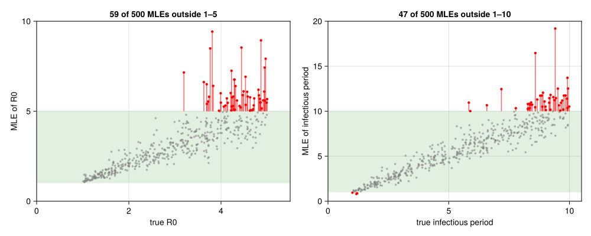

```julia
step("compare", "compare.jl", [RUN], "metrics.csv")
foreach(println, filter(l -> occursin("exact MLE", l), readlines(joinpath(RUN, "compare.log"))))
comp = CSV.read(joinpath(RUN, "comparison.csv"), DataFrame)
mle = comp[comp.method .== "MLE", :]
fig = Figure(size = (1000, 400))
for (j, (par, lab, lo, hi, top)) in enumerate(((:R0, "R0", 1.0, 5.0, 10.0), (:IP, "infectious period", 1.0, 10.0, 20.0)))
    tv, ev = mle[!, Symbol(par, :_true)], mle[!, Symbol(par, :_est)]
    out = (ev .< lo) .| (ev .> hi)
    ax = Axis(fig[1, j]; xlabel = "true $lab", ylabel = "MLE of $lab", limits = ((0.0, hi + 0.5), (0.0, top)),
              title = "$(sum(out)) of $(length(ev)) MLEs outside $(Int(lo))–$(Int(hi))")
    hspan!(ax, lo, hi; color = (:green, 0.12))
    scatter!(ax, tv[.!out], ev[.!out]; color = (:gray, 0.6), markersize = 5)
    linesegments!(ax, vec(permutedims(hcat(Point2f.(tv[out], ev[out]), Point2f.(tv[out], clamp.(ev[out], lo, hi)))));
                  color = (:red, 0.6))
    scatter!(ax, tv[out], ev[out]; color = :red, markersize = 6)
end
fig
```

Shaded: the range the networks were trained on. Gray: MLEs inside it. Red: MLEs outside it; each red line drops to where clipping puts the estimate, the nearest edge of the range.

**Measures**, as Voznica’s (Methods Extended pp. 34–35):

- **MAPE** = 100 × mean |estimate − true value| / true value. Voznica trains with it (p. 24) and reports it as the mean relative error MRE (p. 34); MAPE = 100 × MRE.
- **MRB** = mean (estimate − true value) / true value: the mean relative bias, here in percent.
- **p vs clipped MLE**: Voznica’s paired z-test. It asks whether the difference between a method’s relative errors and the clipped MLE’s, tree by tree, could be chance. A small p means a real difference.
- **Likelihood vs true values**: for each tree, the log-likelihood at the method’s estimate minus the log-likelihood at the true values, averaged over trees. Voznica compared methods this way (p. 35, Supplementary Tab. 3).

MAPE measures how close an estimate is to the true values. One tree of 50 to 199 tips does not pin R0 and IP down, so every method misses. The likelihood column measures how well the estimate explains the observed tree instead. A positive value means the estimate explains that tree better than its true values do; the true values score 0; the MLE has the largest possible value by its definition.

One test tree’s log-likelihood for R0, with each method’s estimate:

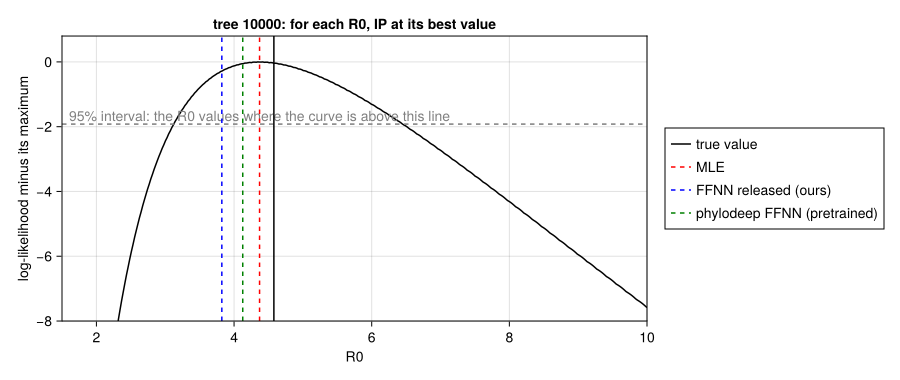

```julia
row = trees[end, :]
gt, pt = parse_newick(String(row.newick)), row.p_sample
θ_t(R0, IP) = (λ = R0 / IP, μ = (1 - pt) / IP, ψ = 0.0, χ = pt / IP)
R0s = range(0.6, 10.0, length = 400)
IPs = exp.(range(log(0.3), log(60.0), length = 400))
prof = [maximum(lbdp_exact(gt; θ_t(R0, IP)...) for IP in IPs) for R0 in R0s]
fig = Figure(size = (900, 380))
ax = Axis(fig[1, 1]; xlabel = "R0", ylabel = "log-likelihood minus its maximum",
          title = "tree $(row.tree): for each R0, IP at its best value", limits = ((1.5, 10.0), (-8.0, 0.8)))
lines!(ax, R0s, prof .- maximum(prof); color = :black)
hlines!(ax, [-1.92]; color = :gray, linestyle = :dash)
text!(ax, 1.6, -1.92; text = "95% interval: the R0 values where the curve is above this line",
      align = (:left, :bottom), color = :gray)
est(meth) = only(comp[(comp.tree .== row.tree) .& (comp.method .== meth), :R0_est])
for (lab, val, col) in (("true value", row.R_0, :black), ("MLE", est("MLE"), :red),
                        ("FFNN released (ours)", est("FFNN released"), :blue),
                        ("phylodeep FFNN (pretrained)", est("phylodeep FFNN (pretrained)"), :green))
    vlines!(ax, [val]; color = col, linestyle = lab == "true value" ? :solid : :dash, label = lab)
end
CairoMakie.Legend(fig[1, 2], ax)
fig
```

## 6. Results

```julia
met = CSV.read(joinpath(RUN, "metrics.csv"), DataFrame)
wide = DataFrame(method = unique(met.method))
for par in ("R0", "IP")
    mm = met[met.parameter .== par, :]
    wide[!, "MAPE $par (%)"] = round.(100 .* mm.MRE, digits = 1)
    wide[!, "MRB $par (%)"] = round.(100 .* mm.MRB, digits = 1)
    wide[!, "p vs clipped MLE, $par"] = round.(mm.p_vs_reference, sigdigits = 2)
end
wide[!, "likelihood vs true values"] = round.(met[met.parameter .== "R0", :mean_ll_vs_true], digits = 2)
wide
```

8×8 DataFrame

| Row | method DataStri… | MAPE R0 (%) Float64 | MRB R0 (%) Float64 | p vs clipped MLE, R0 Float64 | MAPE IP (%) Float64 | MRB IP (%) Float64 | p vs clipped MLE, IP Float64 | likelihood vs true values Float64 |
| --- | --- | --- | --- | --- | --- | --- | --- | --- |
| 1 | MLE | 15.6 | 6.8 | 3.6e-8 | 13.3 | 5.1 | 4.3e-6 | 1.04 |
| 2 | MLE (clipped) | 12.8 | 4.0 | NaN | 11.8 | 3.8 | NaN | 0.18 |
| 3 | CNN paper | 15.3 | -0.9 | 3.3e-5 | 15.3 | -3.9 | 4.0e-6 | -2.46 |
| 4 | CNN released | 14.0 | -0.9 | 0.015 | 13.6 | -1.9 | 0.0024 | -0.39 |
| 5 | FFNN paper | 14.6 | -3.8 | 0.00093 | 13.5 | 0.3 | 0.029 | -3.14 |
| 6 | FFNN released | 13.1 | 0.4 | 0.43 | 11.7 | 0.2 | 0.71 | 0.34 |
| 7 | phylodeep CNN (pretrained) | 11.8 | -1.9 | 0.0027 | 10.3 | -1.1 | 0.00019 | 0.81 |
| 8 | phylodeep FFNN (pretrained) | 11.5 | -1.1 | 6.1e-6 | 10.3 | -0.6 | 0.00026 | 0.89 |

```julia
coverage = met[met.method .== "MLE", :coverage95]
@printf("MLE 95%% interval contains the true value: R0 %.1f%%, IP %.1f%% of 500 trees\n", 100coverage[1], 100coverage[2])
println("with 500 trees this percentage is itself uncertain by about ±1 percentage point; 95% is the target")
```

```
MLE 95% interval contains the true value: R0 93.8%, IP 93.8% of 500 trees
with 500 trees this percentage is itself uncertain by about ±1 percentage point; 95% is the target
```

How to read the table:

1. The MLE’s 95% intervals contain the true values close to 95% of the time, so the likelihood and the intervals work as they should.
2. Clipping lowers the MLE’s MAPE: part of the MLE’s error comes from estimates outside the ranges (the red points above).
3. Our networks, trained on 8,500 trees, come close to the clipped MLE; the `released` FFNN cannot be told apart from it (large p). Dropout (`paper`) costs accuracy at this size. The `paper` versions and the `released` CNN have a negative likelihood column: on average their estimates explain the trees less well than the true values do.
4. phylodeep’s pretrained networks, trained on 3,990,000 trees, have a lower MAPE than the clipped MLE. MAPE is what the networks were trained to make small, and they have learned the ranges; the MLE makes the likelihood large instead. In the likelihood column the MLE is highest, as it must be.
5. For reference, Voznica’s published MAPE for small BD trees (10,000 test trees): CNN-CBLV 14.22% (R0) and 12.47% (IP); FFNN-SS 13.36% and 11.89%.

## 7. True value against estimate

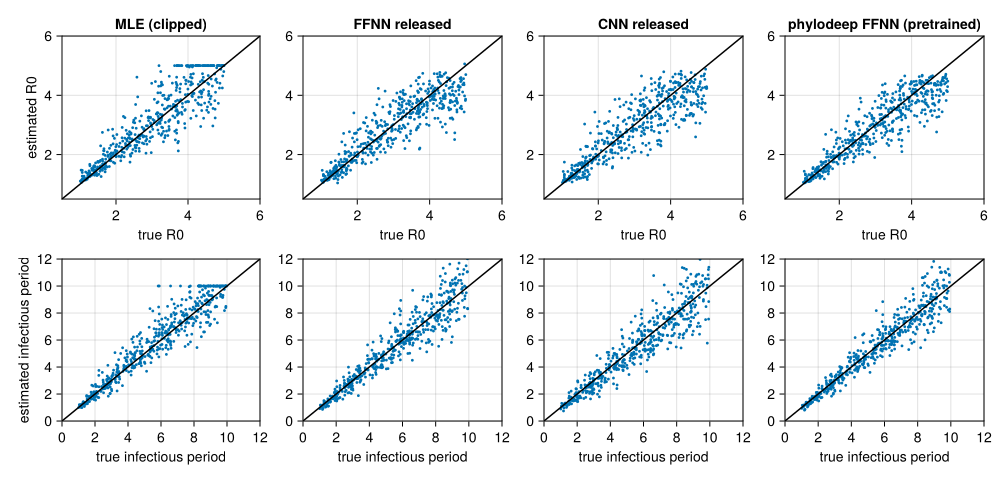

```julia
shown = ["MLE (clipped)", "FFNN released", "CNN released", "phylodeep FFNN (pretrained)"]
fig = Figure(size = (1000, 480))
for (i, (par, lab, lim)) in enumerate(((:R0, "R0", (0.5, 6.0)), (:IP, "infectious period", (0.0, 12.0))))
    for (j, mth) in enumerate(shown)
        d = comp[comp.method .== mth, :]
        ax = Axis(fig[i, j]; title = i == 1 ? mth : "", xlabel = "true $lab", ylabel = j == 1 ? "estimated $lab" : "",
                  limits = (lim, lim))
        scatter!(ax, d[!, Symbol(par, :_true)], d[!, Symbol(par, :_est)]; markersize = 4)
        ablines!(ax, 0, 1; color = :black)
    end
end
fig
```

Each point is one test tree; on the line, the estimate equals the true value. All methods spread more at large values.

# What this run does and does not show

It shows:

1. Every step of the pipeline runs in Julia, from simulation to comparison, and training runs on the GPU.
2. The encoders and the networks equal phylodeep’s (pipeline tests).
3. The comparison works on BD: MLE from the exact likelihood, in the same terms as the networks, with 95% intervals that contain the true values about 95% of the time, and Voznica’s measures and test.

It does not show:

1. Voznica’s accuracy with our own networks: they saw 8,500 training trees, not 3,990,000.
2. The same design as Voznica’s: here each tree’s parameters are drawn independently, Voznica spread them with a Latin hypercube; batches of 500, not 8,000; 500 test trees, not 10,000.
3. Exactly repeatable training: training on the GPU does not repeat to the last digit, so a forced rerun gives slightly different networks. Simulation, encoding and the MLE repeat exactly.
4. Anything for BDEI, BDSS or models with a susceptible pool: this run is BD only.

Next: the full-size run (1,000,000 training trees). Scaled from this run: about 15 minutes to simulate and 25 to encode on 16 threads, and about 12 seconds per CNN pass on the GPU.